# Summer_School_Padova

Author

F. Carabba

# first section

**See code**

```r
3+3
```

```
[1] 6
```

## first subsection

**See code**

```r
head(data)
```

```
   anxiety flexibility mindfulness activity
1 50.17244    44.39524          no  pilates
2 31.47451    47.69823         yes    altro
3 34.03981    65.58708          no  pilates
4 37.06712    50.70508          no    altro
5 48.30549    51.29288          no    altro
6 16.94087    67.15065         yes    altro
```

[output not shown]

**See code**

````markdown
```{r}
str(data)
summary(data)
```
````

**1**

bla bla

```
'data.frame':   300 obs. of  4 variables:
 $ anxiety    : num  50.2 31.5 34 37.1 48.3 ...
 $ flexibility: num  44.4 47.7 65.6 50.7 51.3 ...
 $ mindfulness: chr  "no" "yes" "no" "no" ...
 $ activity   : chr  "pilates" "altro" "pilates" "altro" ...
    anxiety        flexibility    mindfulness          activity
 Min.   : 1.483   Min.   :26.91   Length:300         Length:300
 1st Qu.:25.977   1st Qu.:44.24   Class :character   Class :character
 Median :33.922   Median :49.56   Mode  :character   Mode  :character
 Mean   :33.418   Mean   :50.34
 3rd Qu.:41.974   3rd Qu.:56.32
 Max.   :64.775   Max.   :82.41
```

### first sub-subsection

*plot*

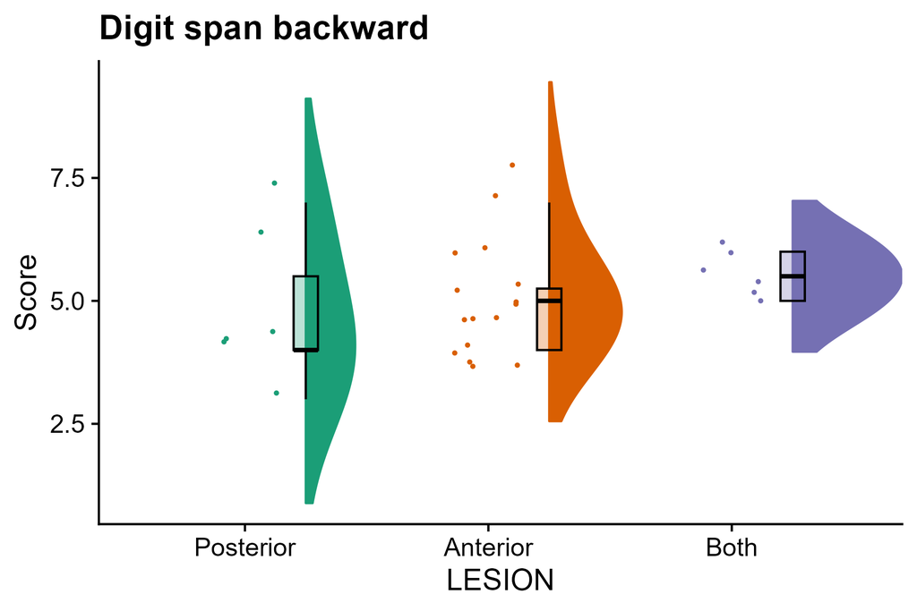

come metto una didascalia?

## second subsection

ecco un altro grafico

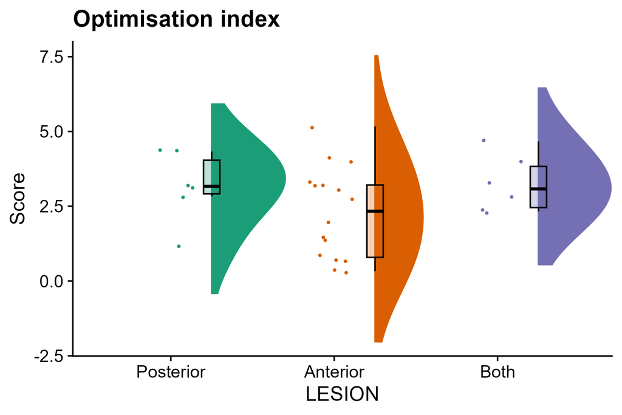

### first sub-subsection

**Come posso cambiare stile di citazione? Come posso mettere un didascalia ad un’immagine? Come posso aggiungere file PDF o file xlsx?**

**See code**

```r
kable(mtcars) %>%
  scroll_box(height = "450px", width = "100%")
```

|  | mpg | cyl | disp | hp | drat | wt | qsec | vs | am | gear | carb |
| --- | --- | --- | --- | --- | --- | --- | --- | --- | --- | --- | --- |
| Mazda RX4 | 21.0 | 6 | 160.0 | 110 | 3.90 | 2.620 | 16.46 | 0 | 1 | 4 | 4 |
| Mazda RX4 Wag | 21.0 | 6 | 160.0 | 110 | 3.90 | 2.875 | 17.02 | 0 | 1 | 4 | 4 |
| Datsun 710 | 22.8 | 4 | 108.0 | 93 | 3.85 | 2.320 | 18.61 | 1 | 1 | 4 | 1 |
| Hornet 4 Drive | 21.4 | 6 | 258.0 | 110 | 3.08 | 3.215 | 19.44 | 1 | 0 | 3 | 1 |
| Hornet Sportabout | 18.7 | 8 | 360.0 | 175 | 3.15 | 3.440 | 17.02 | 0 | 0 | 3 | 2 |
| Valiant | 18.1 | 6 | 225.0 | 105 | 2.76 | 3.460 | 20.22 | 1 | 0 | 3 | 1 |
| Duster 360 | 14.3 | 8 | 360.0 | 245 | 3.21 | 3.570 | 15.84 | 0 | 0 | 3 | 4 |
| Merc 240D | 24.4 | 4 | 146.7 | 62 | 3.69 | 3.190 | 20.00 | 1 | 0 | 4 | 2 |
| Merc 230 | 22.8 | 4 | 140.8 | 95 | 3.92 | 3.150 | 22.90 | 1 | 0 | 4 | 2 |
| Merc 280 | 19.2 | 6 | 167.6 | 123 | 3.92 | 3.440 | 18.30 | 1 | 0 | 4 | 4 |
| Merc 280C | 17.8 | 6 | 167.6 | 123 | 3.92 | 3.440 | 18.90 | 1 | 0 | 4 | 4 |
| Merc 450SE | 16.4 | 8 | 275.8 | 180 | 3.07 | 4.070 | 17.40 | 0 | 0 | 3 | 3 |
| Merc 450SL | 17.3 | 8 | 275.8 | 180 | 3.07 | 3.730 | 17.60 | 0 | 0 | 3 | 3 |
| Merc 450SLC | 15.2 | 8 | 275.8 | 180 | 3.07 | 3.780 | 18.00 | 0 | 0 | 3 | 3 |
| Cadillac Fleetwood | 10.4 | 8 | 472.0 | 205 | 2.93 | 5.250 | 17.98 | 0 | 0 | 3 | 4 |
| Lincoln Continental | 10.4 | 8 | 460.0 | 215 | 3.00 | 5.424 | 17.82 | 0 | 0 | 3 | 4 |
| Chrysler Imperial | 14.7 | 8 | 440.0 | 230 | 3.23 | 5.345 | 17.42 | 0 | 0 | 3 | 4 |
| Fiat 128 | 32.4 | 4 | 78.7 | 66 | 4.08 | 2.200 | 19.47 | 1 | 1 | 4 | 1 |
| Honda Civic | 30.4 | 4 | 75.7 | 52 | 4.93 | 1.615 | 18.52 | 1 | 1 | 4 | 2 |
| Toyota Corolla | 33.9 | 4 | 71.1 | 65 | 4.22 | 1.835 | 19.90 | 1 | 1 | 4 | 1 |
| Toyota Corona | 21.5 | 4 | 120.1 | 97 | 3.70 | 2.465 | 20.01 | 1 | 0 | 3 | 1 |
| Dodge Challenger | 15.5 | 8 | 318.0 | 150 | 2.76 | 3.520 | 16.87 | 0 | 0 | 3 | 2 |
| AMC Javelin | 15.2 | 8 | 304.0 | 150 | 3.15 | 3.435 | 17.30 | 0 | 0 | 3 | 2 |
| Camaro Z28 | 13.3 | 8 | 350.0 | 245 | 3.73 | 3.840 | 15.41 | 0 | 0 | 3 | 4 |
| Pontiac Firebird | 19.2 | 8 | 400.0 | 175 | 3.08 | 3.845 | 17.05 | 0 | 0 | 3 | 2 |
| Fiat X1-9 | 27.3 | 4 | 79.0 | 66 | 4.08 | 1.935 | 18.90 | 1 | 1 | 4 | 1 |
| Porsche 914-2 | 26.0 | 4 | 120.3 | 91 | 4.43 | 2.140 | 16.70 | 0 | 1 | 5 | 2 |
| Lotus Europa | 30.4 | 4 | 95.1 | 113 | 3.77 | 1.513 | 16.90 | 1 | 1 | 5 | 2 |
| Ford Pantera L | 15.8 | 8 | 351.0 | 264 | 4.22 | 3.170 | 14.50 | 0 | 1 | 5 | 4 |
| Ferrari Dino | 19.7 | 6 | 145.0 | 175 | 3.62 | 2.770 | 15.50 | 0 | 1 | 5 | 6 |
| Maserati Bora | 15.0 | 8 | 301.0 | 335 | 3.54 | 3.570 | 14.60 | 0 | 1 | 5 | 8 |
| Volvo 142E | 21.4 | 4 | 121.0 | 109 | 4.11 | 2.780 | 18.60 | 1 | 1 | 4 | 2 |

**See code**

```r
datatable(mtcars)
```

|  | mpg | cyl | disp | hp | drat | wt | qsec | vs | am | gear | carb |
| --- | --- | --- | --- | --- | --- | --- | --- | --- | --- | --- | --- |
| Mazda RX4 | 21 | 6 | 160 | 110 | 3.9 | 2.62 | 16.46 | 0 | 1 | 4 | 4 |
| Mazda RX4 Wag | 21 | 6 | 160 | 110 | 3.9 | 2.875 | 17.02 | 0 | 1 | 4 | 4 |
| Datsun 710 | 22.8 | 4 | 108 | 93 | 3.85 | 2.32 | 18.61 | 1 | 1 | 4 | 1 |
| Hornet 4 Drive | 21.4 | 6 | 258 | 110 | 3.08 | 3.215 | 19.44 | 1 | 0 | 3 | 1 |
| Hornet Sportabout | 18.7 | 8 | 360 | 175 | 3.15 | 3.44 | 17.02 | 0 | 0 | 3 | 2 |
| Valiant | 18.1 | 6 | 225 | 105 | 2.76 | 3.46 | 20.22 | 1 | 0 | 3 | 1 |
| Duster 360 | 14.3 | 8 | 360 | 245 | 3.21 | 3.57 | 15.84 | 0 | 0 | 3 | 4 |
| Merc 240D | 24.4 | 4 | 146.7 | 62 | 3.69 | 3.19 | 20 | 1 | 0 | 4 | 2 |
| Merc 230 | 22.8 | 4 | 140.8 | 95 | 3.92 | 3.15 | 22.9 | 1 | 0 | 4 | 2 |
| Merc 280 | 19.2 | 6 | 167.6 | 123 | 3.92 | 3.44 | 18.3 | 1 | 0 | 4 | 4 |

[output cut: 22 more lines]

Table 1 illustrates a table

**See code**

````markdown
```{r}
#| label: tbl-iris
#| tbl-cap: "Iris Data"
#| code-line-numbers: "|2|3|"

kable(head(iris))
```
````

Table 1: Iris Data

| Sepal.Length | Sepal.Width | Petal.Length | Petal.Width | Species |
| --- | --- | --- | --- | --- |
| 5.1 | 3.5 | 1.4 | 0.2 | setosa |
| 4.9 | 3.0 | 1.4 | 0.2 | setosa |
| 4.7 | 3.2 | 1.3 | 0.2 | setosa |
| 4.6 | 3.1 | 1.5 | 0.2 | setosa |
| 5.0 | 3.6 | 1.4 | 0.2 | setosa |
| 5.4 | 3.9 | 1.7 | 0.4 | setosa |

Listing 1: Basic use of the plot() function

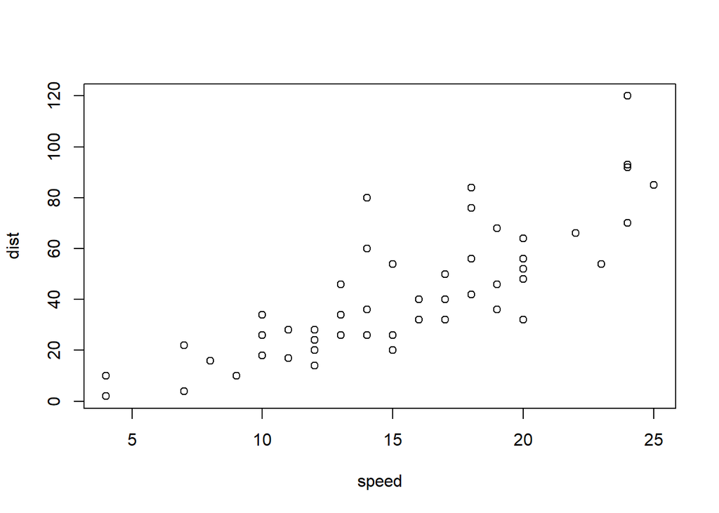

```r
plot(cars)
```

Listing 1 illustrates a basic use of the function plot()

# second section

Ecco la mia tesi magistrale https://hdl.handle.net/20.500.12608/74649

## first subsection

*grassetto corsivo*

Images & Graphs

Figure 1 linea mentale numerica

**See code**

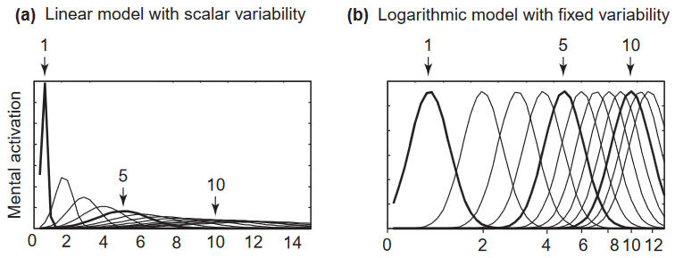

Figure 1: linea mentale numerica due modelli

```r
knitr::include_graphics("Picture/Screenshot 2024-09-01 143156.png")
```

```r
ggplot(data,
       aes(x = flexibility, y = anxiety, color = mindfulness))+
  geom_point()+
    theme(
    axis.title.x = element_text(size = 16),  # ingrandisce il label dell'asse X
    axis.title.y = element_text(size = 16),  # ingrandisce il label dell'asse Y
  )
```

[output not shown]

Listing 2: Basic use of the ggplot() function

## second subsection

Cito altro Klomjai, Katz, and Lackmy-Vallée (2015)

Klomjai, Wanalee, Rose Katz, and Alexandra Lackmy-Vallée. 2015. “Basic Principles of Transcranial Magnetic Stimulation (TMS) and Repetitive TMS (rTMS).” *Annals of Physical and Rehabilitation Medicine* 58 (4): 208–13.

# third section

My link is [here](https://github.com/Oscurofra)

https://github.com/Oscurofra

## first subsection

Cito qualcoosa Valero-Cabré et al. (2017)

Valero-Cabré, Antoni, Julià L Amengual, Chloé Stengel, Alvaro Pascual-Leone, and Olivier A Coubard. 2017. “Transcranial Magnetic Stimulation in Basic and Clinical Neuroscience: A Comprehensive Review of Fundamental Principles and Novel Insights.” *Neuroscience & Biobehavioral Reviews* 83: 381–404.

this is a linear model “equazione del modello lineare”

**See code**

```r
lm(hp ~ mpg*am, data = mtcars)
```

```
Call:
lm(formula = hp ~ mpg * am, data = mtcars)

Coefficients:
(Intercept)          mpg           am       mpg:am
   360.7425     -11.6916      32.3404       0.7768
```

Mettere unq tabella a fianco di un grafico, due immagini a fianco, tue tabelle a fianco

In alternativa a out-width: 100% possiamo usare column: screen-inset-shaded che lo spalma su tutto lo schermo

**See code**

```r
ggplot(data,
       aes(x = flexibility, y = anxiety, color = mindfulness))+
  geom_point()+
    theme(
    axis.title.x = element_text(size = 16),  # ingrandisce il label dell'asse X
    axis.title.y = element_text(size = 16),  # ingrandisce il label dell'asse Y
  )
kable(data) %>%
  scroll_box(height = "450px", width = "100%")
```

[output not shown]

| anxiety | flexibility | mindfulness | activity |
| --- | --- | --- | --- |
| 50.172440 | 44.39524 | no | pilates |
| 31.474508 | 47.69823 | yes | altro |
| 34.039807 | 65.58708 | no | pilates |
| 37.067120 | 50.70508 | no | altro |
| 48.305488 | 51.29288 | no | altro |
| 16.940874 | 67.15065 | yes | altro |
| 36.411704 | 54.60916 | no | pilates |
| 28.795300 | 37.34939 | yes | pilates |
| 43.935452 | 43.13147 | no | pilates |
| 34.983004 | 45.54338 | no | yoga |
| 11.446275 | 62.24082 | yes | yoga |
| 29.112931 | 53.59814 | no | yoga |
| 48.434090 | 54.00771 | no | pilates |
| 29.145208 | 51.10683 | yes | altro |
| 31.265613 | 44.44159 | yes | yoga |
| 1.483110 | 67.86913 | yes | pilates |
| 24.249057 | 54.97850 | yes | altro |
| 40.388909 | 30.33383 | yes | altro |
| 10.975878 | 57.01356 | yes | yoga |
| 47.097003 | 45.27209 | no | yoga |
| 27.398356 | 39.32176 | yes | pilates |
| 25.117776 | 47.82025 | yes | yoga |
| 33.414213 | 39.73996 | yes | yoga |
| 46.535407 | 42.71109 | no | pilates |
| 43.748919 | 43.74961 | no | altro |
| 58.139296 | 33.13307 | no | altro |
| 33.664005 | 58.37787 | no | yoga |
| 23.608899 | 51.53373 | yes | altro |
| 35.750439 | 38.61863 | no | yoga |
| 46.164513 | 62.53815 | no | pilates |

[output cut: 270 more lines]

**See code**

[figure not shown]

(b) Polynomial

Figure 3: One dataset, different models

```r
ggplot(data,
       aes(x = flexibility, y = anxiety, color = mindfulness))+
  geom_point()+
    theme(
    axis.title.x = element_text(size = 16),  # ingrandisce il label dell'asse X
    axis.title.y = element_text(size = 16),  # ingrandisce il label dell'asse Y
  )

ggplot(data,
       aes(x = flexibility, y = anxiety, color = mindfulness))+
  geom_point()+
  geom_smooth()+
    theme(
    axis.title.x = element_text(size = 16),  # ingrandisce il label dell'asse X
    axis.title.y = element_text(size = 16),  # ingrandisce il label dell'asse Y
  )
```

[output not shown]

**See code**

```r
kable(data) %>%
  scroll_box(height = "700px", width = "100%")
kable(mtcars) %>%
  scroll_box(height = "700px", width = "100%")
```

Table 2: Datasets

(a) My data

| anxiety | flexibility | mindfulness | activity |
| --- | --- | --- | --- |
| 50.172440 | 44.39524 | no | pilates |
| 31.474508 | 47.69823 | yes | altro |
| 34.039807 | 65.58708 | no | pilates |
| 37.067120 | 50.70508 | no | altro |
| 48.305488 | 51.29288 | no | altro |
| 16.940874 | 67.15065 | yes | altro |
| 36.411704 | 54.60916 | no | pilates |
| 28.795300 | 37.34939 | yes | pilates |
| 43.935452 | 43.13147 | no | pilates |
| 34.983004 | 45.54338 | no | yoga |
| 11.446275 | 62.24082 | yes | yoga |
| 29.112931 | 53.59814 | no | yoga |
| 48.434090 | 54.00771 | no | pilates |
| 29.145208 | 51.10683 | yes | altro |
| 31.265613 | 44.44159 | yes | yoga |
| 1.483110 | 67.86913 | yes | pilates |
| 24.249057 | 54.97850 | yes | altro |
| 40.388909 | 30.33383 | yes | altro |
| 10.975878 | 57.01356 | yes | yoga |
| 47.097003 | 45.27209 | no | yoga |
| 27.398356 | 39.32176 | yes | pilates |
| 25.117776 | 47.82025 | yes | yoga |
| 33.414213 | 39.73996 | yes | yoga |
| 46.535407 | 42.71109 | no | pilates |
| 43.748919 | 43.74961 | no | altro |
| 58.139296 | 33.13307 | no | altro |
| 33.664005 | 58.37787 | no | yoga |
| 23.608899 | 51.53373 | yes | altro |
| 35.750439 | 38.61863 | no | yoga |
| 46.164513 | 62.53815 | no | pilates |

[output cut: 270 more lines]

(b) Other data (matcars)

|  | mpg | cyl | disp | hp | drat | wt | qsec | vs | am | gear | carb |
| --- | --- | --- | --- | --- | --- | --- | --- | --- | --- | --- | --- |
| Mazda RX4 | 21.0 | 6 | 160.0 | 110 | 3.90 | 2.620 | 16.46 | 0 | 1 | 4 | 4 |
| Mazda RX4 Wag | 21.0 | 6 | 160.0 | 110 | 3.90 | 2.875 | 17.02 | 0 | 1 | 4 | 4 |
| Datsun 710 | 22.8 | 4 | 108.0 | 93 | 3.85 | 2.320 | 18.61 | 1 | 1 | 4 | 1 |
| Hornet 4 Drive | 21.4 | 6 | 258.0 | 110 | 3.08 | 3.215 | 19.44 | 1 | 0 | 3 | 1 |
| Hornet Sportabout | 18.7 | 8 | 360.0 | 175 | 3.15 | 3.440 | 17.02 | 0 | 0 | 3 | 2 |
| Valiant | 18.1 | 6 | 225.0 | 105 | 2.76 | 3.460 | 20.22 | 1 | 0 | 3 | 1 |
| Duster 360 | 14.3 | 8 | 360.0 | 245 | 3.21 | 3.570 | 15.84 | 0 | 0 | 3 | 4 |
| Merc 240D | 24.4 | 4 | 146.7 | 62 | 3.69 | 3.190 | 20.00 | 1 | 0 | 4 | 2 |
| Merc 230 | 22.8 | 4 | 140.8 | 95 | 3.92 | 3.150 | 22.90 | 1 | 0 | 4 | 2 |
| Merc 280 | 19.2 | 6 | 167.6 | 123 | 3.92 | 3.440 | 18.30 | 1 | 0 | 4 | 4 |
| Merc 280C | 17.8 | 6 | 167.6 | 123 | 3.92 | 3.440 | 18.90 | 1 | 0 | 4 | 4 |
| Merc 450SE | 16.4 | 8 | 275.8 | 180 | 3.07 | 4.070 | 17.40 | 0 | 0 | 3 | 3 |
| Merc 450SL | 17.3 | 8 | 275.8 | 180 | 3.07 | 3.730 | 17.60 | 0 | 0 | 3 | 3 |
| Merc 450SLC | 15.2 | 8 | 275.8 | 180 | 3.07 | 3.780 | 18.00 | 0 | 0 | 3 | 3 |
| Cadillac Fleetwood | 10.4 | 8 | 472.0 | 205 | 2.93 | 5.250 | 17.98 | 0 | 0 | 3 | 4 |
| Lincoln Continental | 10.4 | 8 | 460.0 | 215 | 3.00 | 5.424 | 17.82 | 0 | 0 | 3 | 4 |
| Chrysler Imperial | 14.7 | 8 | 440.0 | 230 | 3.23 | 5.345 | 17.42 | 0 | 0 | 3 | 4 |
| Fiat 128 | 32.4 | 4 | 78.7 | 66 | 4.08 | 2.200 | 19.47 | 1 | 1 | 4 | 1 |
| Honda Civic | 30.4 | 4 | 75.7 | 52 | 4.93 | 1.615 | 18.52 | 1 | 1 | 4 | 2 |
| Toyota Corolla | 33.9 | 4 | 71.1 | 65 | 4.22 | 1.835 | 19.90 | 1 | 1 | 4 | 1 |
| Toyota Corona | 21.5 | 4 | 120.1 | 97 | 3.70 | 2.465 | 20.01 | 1 | 0 | 3 | 1 |
| Dodge Challenger | 15.5 | 8 | 318.0 | 150 | 2.76 | 3.520 | 16.87 | 0 | 0 | 3 | 2 |
| AMC Javelin | 15.2 | 8 | 304.0 | 150 | 3.15 | 3.435 | 17.30 | 0 | 0 | 3 | 2 |
| Camaro Z28 | 13.3 | 8 | 350.0 | 245 | 3.73 | 3.840 | 15.41 | 0 | 0 | 3 | 4 |
| Pontiac Firebird | 19.2 | 8 | 400.0 | 175 | 3.08 | 3.845 | 17.05 | 0 | 0 | 3 | 2 |
| Fiat X1-9 | 27.3 | 4 | 79.0 | 66 | 4.08 | 1.935 | 18.90 | 1 | 1 | 4 | 1 |
| Porsche 914-2 | 26.0 | 4 | 120.3 | 91 | 4.43 | 2.140 | 16.70 | 0 | 1 | 5 | 2 |
| Lotus Europa | 30.4 | 4 | 95.1 | 113 | 3.77 | 1.513 | 16.90 | 1 | 1 | 5 | 2 |
| Ford Pantera L | 15.8 | 8 | 351.0 | 264 | 4.22 | 3.170 | 14.50 | 0 | 1 | 5 | 4 |
| Ferrari Dino | 19.7 | 6 | 145.0 | 175 | 3.62 | 2.770 | 15.50 | 0 | 1 | 5 | 6 |
| Maserati Bora | 15.0 | 8 | 301.0 | 335 | 3.54 | 3.570 | 14.60 | 0 | 1 | 5 | 8 |
| Volvo 142E | 21.4 | 4 | 121.0 | 109 | 4.11 | 2.780 | 18.60 | 1 | 1 | 4 | 2 |

**See code**

```r
ggplot(data,
       aes(x = flexibility, y = anxiety, color = mindfulness))+
  geom_point()+
    theme(
      axis.title.x = element_text(size = 16),
      axis.title.y = element_text(size = 16),
  )
```

[output not shown]

**See code**

```r
kable(head(data))
```

| anxiety | flexibility | mindfulness | activity |
| --- | --- | --- | --- |
| 50.17244 | 44.39524 | no | pilates |
| 31.47451 | 47.69823 | yes | altro |
| 34.03981 | 65.58708 | no | pilates |
| 37.06712 | 50.70508 | no | altro |
| 48.30549 | 51.29288 | no | altro |
| 16.94087 | 67.15065 | yes | altro |